# House_Prediction_Final (1) (1)

**3 - create new column `renovation_status` from `yr_renovated`**

```python
df['renovation_status'] = np.where(df['yr_renovated'] == 0, 'notrenovated', 'renovated')
```

```python
df.to_csv('Downloads/COLUMNS.csv',index=False)
```

**Lets check % or count of Renovated Houses**

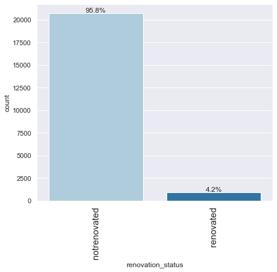

```python
 labeled_barplot(df, "renovation_status", perc=True, n=5)
```

**Are the prices influenced by renovations?**

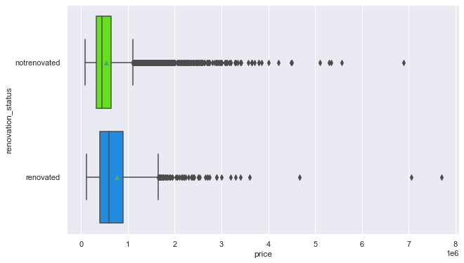

```python
plt.figure(figsize=(10, 6))
sns.boxplot(
    data=df, y="renovation_status", x="price", palette="gist_rainbow", orient='h',showmeans=True
)
plt.show()
```

**Lets check if the houses quality are based on their renovations?**

```
renovation_status  notrenovated  renovated    All
quality
All                       20683        914  21597
7.0                        8639        336   8975
8.0                        5799        265   6064
9.0                        2477        138   2615
6.0                        1941         97   2038
10.0                       1084         50   1134
11.0                        384         15    399
5.0                         236          6    242
12.0                         86          3     89
13.0                         10          3     13
4.0                          26          1     27
3.0                           1          0      1
------------------------------------------------------------------------------------------------------------------------
```

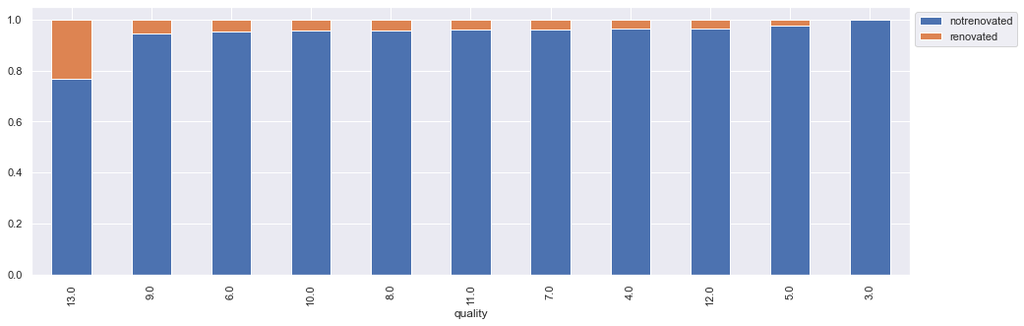

```python
stacked_barplot(df, "quality", "renovation_status")
```

**Lets check the exact locations of the houses in the dataset with `long` and `lat`**

```python
# Install folium for map plotting
!pip install folium
```

```python
import folium

from folium.plugins import FastMarkerCluster
```

```python
## Let's study Latitude and Longitue features

lat = df['lat'].tolist()

lon = df['long'].tolist()

locations = list(zip(lat, lon))


map1 = folium.Map(location=[47.7776, -122.519], zoom_start=12)

FastMarkerCluster(locations).add_to(map1)

map1
```

[interactive chart not shown]

```python
df.info()
```

```
<class 'pandas.core.frame.DataFrame'>
Int64Index: 21597 entries, 0 to 21612
Data columns (total 26 columns):
 #   Column             Non-Null Count  Dtype
---  ------             --------------  -----
 0   cid                21597 non-null  float64
 1   dayhours           21597 non-null  object
 2   price              21597 non-null  float64
 3   room_bed           21597 non-null  float64
 4   room_bath          21597 non-null  float64
 5   living_measure     21597 non-null  float64
 6   lot_measure        21597 non-null  float64
 7   ceil               21597 non-null  float64
 8   coast              21597 non-null  float64
 9   sight              21597 non-null  float64
```

[output cut: 18 more lines]

**Outlier Check**

```python
Outl = df.copy()
```

```python
col = ['cid', 'dayhours','yr_built', 'yr_renovated','zipcode','yr_sold','renovation_status']
```

```python
outl = Outl.drop(col, axis=1)
```

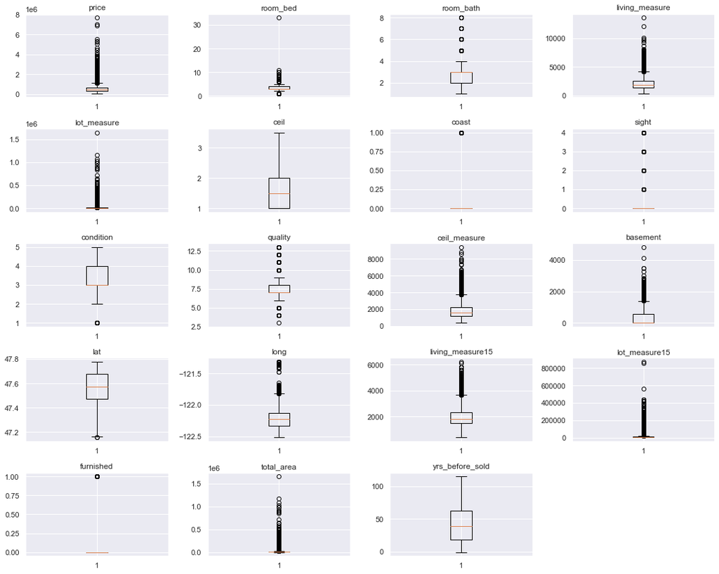

```python
# outlier detection using boxplot
numeric_columns = outl.select_dtypes(include=np.number).columns.tolist()

plt.figure(figsize=(15, 12))

# Ensure the number of subplots matches the number of numeric columns
num_subplots = min(len(numeric_columns), 20)

for i, variable in enumerate(numeric_columns[:num_subplots]):
    plt.subplot(5, 4, i + 1)
    plt.boxplot(outl[variable], whis=1.5)
    plt.title(variable)

# Adjust layout to prevent overlapping
plt.tight_layout()

plt.show()
```

- There are quite a few outliers in the data
- However, we will not treat them as they are proper values.
- In real-world outliers exist, and these outliers should be incorporated in the model building.

### Preparing the data for the models building

- We want to predict the prices of houses,which is our target varibale.
- Before we proceed to build the models;
  - We'll drop 'yr_built', 'cid', 'yr_renovated', 'yr_sold', 'total_area' and 'dayhours'
    - Why drop these independent variables:
    - `cid` - Not significant in the model building - they are just codes assigned to the houses
    - `renovation_status (new variable)` has been created from `yr_renovated`.
    - `yr_sold`, `yr_built` & `dayhour` - `yr_before_sold (new variable)` has been created to replace these variables
    - `total_area` comprises; living_measure & lot_measure. Once were adding these two variables to the model, total_area, which is their sum can be dropped
  - We'll encode `renovation_status` and `zipcode`, for Linear regression model
- We'll split the data into train and test to be able to evaluate the model that we build on the train data.
  - Test data will cover 30% of the dataset
  - Train data will also cover 70%

**We will build the following Regression models using the train data and then check their performances**

- Linear Regression Model (OLS)
- Decision Tree Regressor Model
- Random Forest Regressor Model
- XGBoost Regressor Model

**The models evaluation metrices:**

- RMSE (Root Mean Squared Error)
- MAE (Mean Absolute Error)
- R-squared (Coefficient of Determination)
- Adjusted R-squared
- MAPE (Mean Absolute Percentage Error)

```python
df.columns
```

```
Index(['cid', 'dayhours', 'price', 'room_bed', 'room_bath', 'living_measure',
       'lot_measure', 'ceil', 'coast', 'sight', 'condition', 'quality',
       'ceil_measure', 'basement', 'yr_built', 'yr_renovated', 'zipcode',
       'lat', 'long', 'living_measure15', 'lot_measure15', 'furnished',
       'total_area', 'yr_sold', 'yrs_before_sold', 'renovation_status'],
      dtype='object')
```

```python
df.info()
```

```
<class 'pandas.core.frame.DataFrame'>
Int64Index: 21597 entries, 0 to 21612
Data columns (total 26 columns):
 #   Column             Non-Null Count  Dtype
---  ------             --------------  -----
 0   cid                21597 non-null  float64
 1   dayhours           21597 non-null  object
 2   price              21597 non-null  float64
 3   room_bed           21597 non-null  float64
 4   room_bath          21597 non-null  float64
 5   living_measure     21597 non-null  float64
 6   lot_measure        21597 non-null  float64
 7   ceil               21597 non-null  float64
 8   coast              21597 non-null  float64
 9   sight              21597 non-null  float64
```

[output cut: 18 more lines]

#### Dataype convertion - zipcode

```python
df['zipcode'] = df['zipcode'].astype('object')
```

```python
df.info()
```

```
<class 'pandas.core.frame.DataFrame'>
Int64Index: 21597 entries, 0 to 21612
Data columns (total 26 columns):
 #   Column             Non-Null Count  Dtype
---  ------             --------------  -----
 0   cid                21597 non-null  float64
 1   dayhours           21597 non-null  object
 2   price              21597 non-null  float64
 3   room_bed           21597 non-null  float64
 4   room_bath          21597 non-null  float64
 5   living_measure     21597 non-null  float64
 6   lot_measure        21597 non-null  float64
 7   ceil               21597 non-null  float64
 8   coast              21597 non-null  float64
 9   sight              21597 non-null  float64
```

[output cut: 18 more lines]

#### Lets drop yr_built, cid, yr_renovated, yr_sold, total_area and dayhours

```python
col3 = ['cid', 'dayhours','yr_built', 'yr_renovated', 'yr_sold','total_area']
```

```python
df = df.drop(col3, axis=1)
```

```python
df.info()
```

```
<class 'pandas.core.frame.DataFrame'>
Int64Index: 21597 entries, 0 to 21612
Data columns (total 20 columns):
 #   Column             Non-Null Count  Dtype
---  ------             --------------  -----
 0   price              21597 non-null  float64
 1   room_bed           21597 non-null  float64
 2   room_bath          21597 non-null  float64
 3   living_measure     21597 non-null  float64
 4   lot_measure        21597 non-null  float64
 5   ceil               21597 non-null  float64
 6   coast              21597 non-null  float64
 7   sight              21597 non-null  float64
 8   condition          21597 non-null  float64
 9   quality            21597 non-null  float64
 10  ceil_measure       21597 non-null  float64
 11  basement           21597 non-null  float64
 12  zipcode            21597 non-null  object
 13  lat                21597 non-null  float64
 14  long               21597 non-null  float64
 15  living_measure15   21597 non-null  float64
 16  lot_measure15      21597 non-null  float64
 17  furnished          21597 non-null  float64
 18  yrs_before_sold    21597 non-null  float64
 19  renovation_status  21597 non-null  object
dtypes: float64(18), object(2)
memory usage: 3.5+ MB
```

### LINEAR REGRESSION MODEL

```python
df2 = df.copy()
```

```python
df2
```

|  | price | room_bed | room_bath | living_measure | lot_measure | ceil | coast | sight | condition | quality | ceil_measure | basement | zipcode | lat | long | living_measure15 | lot_measure15 | furnished | yrs_before_sold | renovation_status |
| --- | --- | --- | --- | --- | --- | --- | --- | --- | --- | --- | --- | --- | --- | --- | --- | --- | --- | --- | --- | --- |
| 0 | 600000.00 | 4.00 | 2.00 | 3050.00 | 9440.00 | 1.00 | 0.00 | 0.00 | 3.00 | 8.00 | 1800.00 | 1250.00 | 98034.00 | 47.72 | -122.18 | 2020.00 | 8660.00 | 0.00 | 49.00 | notrenovated |
| 1 | 190000.00 | 2.00 | 1.00 | 670.00 | 3101.00 | 1.00 | 0.00 | 0.00 | 4.00 | 6.00 | 670.00 | 0.00 | 98118.00 | 47.55 | -122.27 | 1660.00 | 4100.00 | 0.00 | 67.00 | notrenovated |
| 2 | 735000.00 | 4.00 | 3.00 | 3040.00 | 2415.00 | 2.00 | 1.00 | 4.00 | 3.00 | 8.00 | 3040.00 | 0.00 | 98118.00 | 47.52 | -122.26 | 2620.00 | 2433.00 | 0.00 | 48.00 | notrenovated |
| 3 | 257000.00 | 3.00 | 3.00 | 1740.00 | 3721.00 | 2.00 | 0.00 | 0.00 | 3.00 | 8.00 | 1740.00 | 0.00 | 98002.00 | 47.34 | -122.21 | 2030.00 | 3794.00 | 0.00 | 5.00 | notrenovated |
| 4 | 450000.00 | 2.00 | 1.00 | 1120.00 | 4590.00 | 1.00 | 0.00 | 0.00 | 3.00 | 7.00 | 1120.00 | 0.00 | 98118.00 | 47.57 | -122.28 | 1120.00 | 5100.00 | 0.00 | 91.00 | notrenovated |
| ... | ... | ... | ... | ... | ... | ... | ... | ... | ... | ... | ... | ... | ... | ... | ... | ... | ... | ... | ... | ... |
| 21608 | 685530.00 | 4.00 | 3.00 | 3130.00 | 60467.00 | 2.00 | 0.00 | 0.00 | 3.00 | 9.00 | 3130.00 | 0.00 | 98014.00 | 47.66 | -121.96 | 2780.00 | 44224.00 | 1.00 | 19.00 | notrenovated |
| 21609 | 535000.00 | 2.00 | 1.00 | 1030.00 | 4841.00 | 1.00 | 0.00 | 0.00 | 3.00 | 7.00 | 920.00 | 110.00 | 98103.00 | 47.69 | -122.34 | 1530.00 | 4944.00 | 0.00 | 75.00 | notrenovated |
| 21610 | 998000.00 | 3.00 | 4.00 | 3710.00 | 34412.00 | 2.00 | 0.00 | 0.00 | 3.00 | 10.00 | 2910.00 | 800.00 | 98075.00 | 47.59 | -122.04 | 2390.00 | 34412.00 | 1.00 | 36.00 | notrenovated |
| 21611 | 262000.00 | 4.00 | 3.00 | 1560.00 | 7800.00 | 2.00 | 0.00 | 0.00 | 3.00 | 7.00 | 1560.00 | 0.00 | 98168.00 | 47.51 | -122.32 | 1160.00 | 7800.00 | 0.00 | 18.00 | notrenovated |
| 21612 | 1150000.00 | 4.00 | 3.00 | 1940.00 | 4875.00 | 2.00 | 0.00 | 0.00 | 4.00 | 9.00 | 1940.00 | 0.00 | 98112.00 | 47.64 | -122.30 | 1790.00 | 4875.00 | 1.00 | 89.00 | notrenovated |

21597 rows × 20 columns

**Defining X-Independent and y-Dependent variables**

```python
X = df2.drop(["price"], axis=1)
y = df2["price"]

print(X.head())
print(y.head())
```

```
   room_bed  room_bath  living_measure  lot_measure  ceil  coast  sight  \
0      4.00       2.00         3050.00      9440.00  1.00   0.00   0.00
1      2.00       1.00          670.00      3101.00  1.00   0.00   0.00
2      4.00       3.00         3040.00      2415.00  2.00   1.00   4.00
3      3.00       3.00         1740.00      3721.00  2.00   0.00   0.00
4      2.00       1.00         1120.00      4590.00  1.00   0.00   0.00

   condition  quality  ceil_measure  basement  zipcode   lat    long  \
0       3.00     8.00       1800.00   1250.00 98034.00 47.72 -122.18
1       4.00     6.00        670.00      0.00 98118.00 47.55 -122.27
2       3.00     8.00       3040.00      0.00 98118.00 47.52 -122.26
3       3.00     8.00       1740.00      0.00 98002.00 47.34 -122.21
4       3.00     7.00       1120.00      0.00 98118.00 47.57 -122.28

   living_measure15  lot_measure15  furnished  yrs_before_sold  \
```

[output cut: 18 more lines]

**let's add the intercept to data**

```python
X = sm.add_constant(X)
```

**Creating dummy variables**

```python
X = pd.get_dummies(
    X,
    columns=X.select_dtypes(include=["object"]).columns.tolist(),
    drop_first=True,
)
X.head()
```

|  | const | room_bed | room_bath | living_measure | lot_measure | ceil | coast | sight | condition | quality | ... | zipcode_98148.0 | zipcode_98155.0 | zipcode_98166.0 | zipcode_98168.0 | zipcode_98177.0 | zipcode_98178.0 | zipcode_98188.0 | zipcode_98198.0 | zipcode_98199.0 | renovation_status_renovated |
| --- | --- | --- | --- | --- | --- | --- | --- | --- | --- | --- | --- | --- | --- | --- | --- | --- | --- | --- | --- | --- | --- |
| 0 | 1.00 | 4.00 | 2.00 | 3050.00 | 9440.00 | 1.00 | 0.00 | 0.00 | 3.00 | 8.00 | ... | 0 | 0 | 0 | 0 | 0 | 0 | 0 | 0 | 0 | 0 |
| 1 | 1.00 | 2.00 | 1.00 | 670.00 | 3101.00 | 1.00 | 0.00 | 0.00 | 4.00 | 6.00 | ... | 0 | 0 | 0 | 0 | 0 | 0 | 0 | 0 | 0 | 0 |
| 2 | 1.00 | 4.00 | 3.00 | 3040.00 | 2415.00 | 2.00 | 1.00 | 4.00 | 3.00 | 8.00 | ... | 0 | 0 | 0 | 0 | 0 | 0 | 0 | 0 | 0 | 0 |
| 3 | 1.00 | 3.00 | 3.00 | 1740.00 | 3721.00 | 2.00 | 0.00 | 0.00 | 3.00 | 8.00 | ... | 0 | 0 | 0 | 0 | 0 | 0 | 0 | 0 | 0 | 0 |
| 4 | 1.00 | 2.00 | 1.00 | 1120.00 | 4590.00 | 1.00 | 0.00 | 0.00 | 3.00 | 7.00 | ... | 0 | 0 | 0 | 0 | 0 | 0 | 0 | 0 | 0 | 0 |

5 rows × 88 columns

**Feature Scaling**

```python
col5=['room_bed',"room_bath",'living_measure','lot_measure','ceil','coast','sight','condition','quality','ceil_measure','basement','lat','long','living_measure15','lot_measure15','yrs_before_sold']
```

```python
from sklearn.preprocessing import StandardScaler
st=StandardScaler()
X[col5] = st.fit_transform(X[col5])
```

```python
X
```

|  | const | room_bed | room_bath | living_measure | lot_measure | ceil | coast | sight | condition | quality | ... | zipcode_98148.0 | zipcode_98155.0 | zipcode_98166.0 | zipcode_98168.0 | zipcode_98177.0 | zipcode_98178.0 | zipcode_98188.0 | zipcode_98198.0 | zipcode_98199.0 | renovation_status_renovated |
| --- | --- | --- | --- | --- | --- | --- | --- | --- | --- | --- | --- | --- | --- | --- | --- | --- | --- | --- | --- | --- | --- |
| 0 | 1.00 | 0.68 | -0.48 | 1.06 | -0.14 | -0.92 | -0.09 | -0.31 | -0.63 | 0.29 | ... | 0 | 0 | 0 | 0 | 0 | 0 | 0 | 0 | 0 | 0 |
| 1 | 1.00 | -1.48 | -1.57 | -1.54 | -0.29 | -0.92 | -0.09 | -0.31 | 0.91 | -1.41 | ... | 0 | 0 | 0 | 0 | 0 | 0 | 0 | 0 | 0 | 0 |
| 2 | 1.00 | 0.68 | 0.60 | 1.05 | -0.31 | 0.94 | 11.54 | 4.92 | -0.63 | 0.29 | ... | 0 | 0 | 0 | 0 | 0 | 0 | 0 | 0 | 0 | 0 |
| 3 | 1.00 | -0.40 | 0.60 | -0.37 | -0.27 | 0.94 | -0.09 | -0.31 | -0.63 | 0.29 | ... | 0 | 0 | 0 | 0 | 0 | 0 | 0 | 0 | 0 | 0 |
| 4 | 1.00 | -1.48 | -1.57 | -1.05 | -0.25 | -0.92 | -0.09 | -0.31 | -0.63 | -0.56 | ... | 0 | 0 | 0 | 0 | 0 | 0 | 0 | 0 | 0 | 0 |
| ... | ... | ... | ... | ... | ... | ... | ... | ... | ... | ... | ... | ... | ... | ... | ... | ... | ... | ... | ... | ... | ... |
| 21608 | 1.00 | 0.68 | 0.60 | 1.14 | 1.10 | 0.94 | -0.09 | -0.31 | -0.63 | 1.14 | ... | 0 | 0 | 0 | 0 | 0 | 0 | 0 | 0 | 0 | 0 |
| 21609 | 1.00 | -1.48 | -1.57 | -1.14 | -0.25 | -0.92 | -0.09 | -0.31 | -0.63 | -0.56 | ... | 0 | 0 | 0 | 0 | 0 | 0 | 0 | 0 | 0 | 0 |
| 21610 | 1.00 | -0.40 | 1.69 | 1.78 | 0.47 | 0.94 | -0.09 | -0.31 | -0.63 | 2.00 | ... | 0 | 0 | 0 | 0 | 0 | 0 | 0 | 0 | 0 | 0 |
| 21611 | 1.00 | 0.68 | 0.60 | -0.57 | -0.18 | 0.94 | -0.09 | -0.31 | -0.63 | -0.56 | ... | 0 | 0 | 0 | 1 | 0 | 0 | 0 | 0 | 0 | 0 |
| 21612 | 1.00 | 0.68 | 0.60 | -0.15 | -0.25 | 0.94 | -0.09 | -0.31 | 0.91 | 1.14 | ... | 0 | 0 | 0 | 0 | 0 | 0 | 0 | 0 | 0 | 0 |

21597 rows × 88 columns

### Splitting the data in 70:30 ratio for train to test data

```python
x_train, x_test, y_train, y_test = train_test_split(X, y, test_size=0.3, random_state=42)
```

```python
print("Number of rows in train data =", x_train.shape[0])
print("Number of rows in test data =", x_test.shape[0])
```

```
Number of rows in train data = 15117
Number of rows in test data = 6480
```

```python
olsmodel = sm.OLS(y_train, x_train).fit()
print(olsmodel.summary())
```

```
                            OLS Regression Results
==============================================================================
Dep. Variable:                  price   R-squared:                       0.808
Model:                            OLS   Adj. R-squared:                  0.807
Method:                 Least Squares   F-statistic:                     726.6
Date:                Fri, 22 Dec 2023   Prob (F-statistic):               0.00
Time:                        16:12:54   Log-Likelihood:            -2.0261e+05
No. Observations:               15117   AIC:                         4.054e+05
Df Residuals:                   15029   BIC:                         4.061e+05
Df Model:                          87
Covariance Type:            nonrobust
===============================================================================================
                                  coef    std err          t      P>|t|      [0.025      0.975]
-----------------------------------------------------------------------------------------------
const                        3.852e+05   2.22e+04     17.335      0.000    3.42e+05    4.29e+05
room_bed                    -2.062e+04   1666.273    -12.375      0.000   -2.39e+04   -1.74e+04
room_bath                    1.114e+04   2404.675      4.634      0.000    6430.798    1.59e+04
living_measure               9.733e+04   4.45e+04      2.190      0.029    1.02e+04    1.84e+05
lot_measure                  1.052e+04   1942.195      5.417      0.000    6713.203    1.43e+04
ceil                        -2.586e+04   2053.118    -12.597      0.000   -2.99e+04   -2.18e+04
coast                        5.518e+04   1479.634     37.293      0.000    5.23e+04    5.81e+04
sight                        4.243e+04   1616.588     26.248      0.000    3.93e+04    4.56e+04
condition                     1.57e+04   1493.300     10.514      0.000    1.28e+04    1.86e+04
quality                      6.391e+04   3029.149     21.098      0.000     5.8e+04    6.98e+04
ceil_measure                 8.885e+04   4.01e+04      2.215      0.027    1.02e+04    1.67e+05
basement                     1.415e+04   2.15e+04      0.660      0.510   -2.79e+04    5.62e+04
lat                           2.61e+04   1.06e+04      2.460      0.014    5303.507    4.69e+04
long                        -1.971e+04   7500.622     -2.628      0.009   -3.44e+04   -5010.291
living_measure15             1029.1974   2368.669      0.435      0.664   -3613.682    5672.077
lot_measure15               -2666.3502   2000.673     -1.333      0.183   -6587.912    1255.212
furnished                    2.248e+04   5585.931      4.024      0.000    1.15e+04    3.34e+04
yrs_before_sold              1.897e+04   2283.084      8.311      0.000    1.45e+04    2.34e+04
zipcode_98002.0              3.701e+04   1.75e+04      2.110      0.035    2635.649    7.14e+04
zipcode_98003.0             -1.705e+04   1.55e+04     -1.102      0.271   -4.74e+04    1.33e+04
zipcode_98004.0              7.216e+05   2.82e+04     25.562      0.000    6.66e+05    7.77e+05
zipcode_98005.0              2.725e+05   3.02e+04      9.010      0.000    2.13e+05    3.32e+05
zipcode_98006.0              2.271e+05   2.47e+04      9.208      0.000    1.79e+05    2.75e+05
zipcode_98007.0              2.079e+05    3.1e+04      6.712      0.000    1.47e+05    2.69e+05
zipcode_98008.0              2.017e+05   2.95e+04      6.838      0.000    1.44e+05     2.6e+05
zipcode_98010.0               9.54e+04   2.66e+04      3.587      0.000    4.33e+04    1.48e+05
```

[output cut: 56 more lines]

```
zipcode_98177.0               1.13e+05   3.69e+04      3.061      0.002    4.07e+04    1.85e+05
zipcode_98178.0              1.093e+04   2.15e+04      0.508      0.612   -3.13e+04    5.31e+04
zipcode_98188.0              1.243e+04   2.17e+04      0.574      0.566      -3e+04    5.49e+04
zipcode_98198.0             -2.134e+04   1.66e+04     -1.288      0.198   -5.38e+04    1.11e+04
zipcode_98199.0              3.127e+05   3.03e+04     10.324      0.000    2.53e+05    3.72e+05
renovation_status_renovated  2.588e+04   7064.088      3.663      0.000     1.2e+04    3.97e+04
==============================================================================
Omnibus:                    14922.736   Durbin-Watson:                   2.001
Prob(Omnibus):                  0.000   Jarque-Bera (JB):          3557079.089
Skew:                           4.286   Prob(JB):                         0.00
Kurtosis:                      77.658   Cond. No.                         349.
==============================================================================

Notes:
[1] Standard Errors assume that the covariance matrix of the errors is correctly specified.
```

### Model Performance Check

```python
# function to compute adjusted R-squared
def adj_r2_score(predictors, targets, predictions):
    r2 = r2_score(targets, predictions)
    n = predictors.shape[0]
    k = predictors.shape[1]
    return 1 - ((1 - r2) * (n - 1) / (n - k - 1))


# function to compute MAPE
def mape_score(targets, predictions):
    return np.mean(np.abs(targets - predictions) / targets) * 100


# function to compute different metrics to check performance of a regression model
def model_performance_regression(model, predictors, target):
    """
    Function to compute different metrics to check regression model performance

    model: regressor
    predictors: independent variables
    target: dependent variable
    """

    # predicting using the independent variables
    pred = model.predict(predictors)

    r2 = r2_score(target, pred)  # to compute R-squared
    adjr2 = adj_r2_score(predictors, target, pred)  # to compute adjusted R-squared
    rmse = np.sqrt(mean_squared_error(target, pred))  # to compute RMSE
    mae = mean_absolute_error(target, pred)  # to compute MAE
    mape = mape_score(target, pred)  # to compute MAPE

    # creating a dataframe of metrics
    df_perf = pd.DataFrame(
        {
            "RMSE": rmse,
            "MAE": mae,
            "R-squared": r2,
            "Adj. R-squared": adjr2,
            "MAPE": mape,
        },
        index=[0],
    )

    return df_perf
```

```python
# checking model performance on train set (seen 70% data)
print("Training Performance\n")
olsmodel_train_perf = model_performance_regression(olsmodel, x_train, y_train)
olsmodel_train_perf
```

```
Training Performance
```

|  | RMSE | MAE | R-squared | Adj. R-squared | MAPE |
| --- | --- | --- | --- | --- | --- |
| 0 | 160142.86 | 95391.88 | 0.81 | 0.81 | 19.54 |

```python
# checking model performance on test set (seen 30% data)
print("Test Performance\n")
olsmodel_test_perf = model_performance_regression(olsmodel, x_test, y_test)
olsmodel_test_perf
```

```
Test Performance
```

|  | RMSE | MAE | R-squared | Adj. R-squared | MAPE |
| --- | --- | --- | --- | --- | --- |
| 0 | 163489.01 | 96960.57 | 0.81 | 0.80 | 19.49 |

### Checking Linear Regression Assumptions

We will be checking the following Linear Regression assumptions:

- No Multicollinearity
- Linearity of variables
- Independence of error terms
- Normality of error terms
- No Heteroscedasticity

```python
#Let's define a function to check VIF.

def checking_vif(predictors):
    vif = pd.DataFrame()
    vif["feature"] = predictors.columns

    # calculating VIF for each feature
    vif["VIF"] = [
        variance_inflation_factor(predictors.values, i)
        for i in range(len(predictors.columns))
    ]
    return vif
```

```python
# check VIF on train data
checking_vif(x_train).sort_values(by='VIF', ascending=False).head(50)
```

|  | feature | VIF |
| --- | --- | --- |
| 3 | living_measure | 1159.99 |
| 10 | ceil_measure | 942.04 |
| 0 | const | 289.32 |
| 11 | basement | 271.63 |
| 12 | lat | 65.72 |
| 13 | long | 32.91 |
| 39 | zipcode_98034.0 | 17.28 |
| 74 | zipcode_98133.0 | 16.84 |
| 68 | zipcode_98117.0 | 16.11 |
| 45 | zipcode_98052.0 | 15.69 |
| 79 | zipcode_98155.0 | 15.65 |
| 59 | zipcode_98103.0 | 15.31 |
| 66 | zipcode_98115.0 | 15.27 |
| 46 | zipcode_98053.0 | 12.87 |
| 72 | zipcode_98125.0 | 12.56 |
| 38 | zipcode_98033.0 | 11.59 |
| 53 | zipcode_98072.0 | 11.30 |
| 33 | zipcode_98028.0 | 11.26 |
| 54 | zipcode_98074.0 | 10.56 |
| 82 | zipcode_98177.0 | 8.72 |
| 28 | zipcode_98019.0 | 8.64 |
| 55 | zipcode_98075.0 | 8.40 |
| 86 | zipcode_98199.0 | 8.30 |
| 51 | zipcode_98065.0 | 8.28 |
| 56 | zipcode_98077.0 | 8.22 |
| 22 | zipcode_98006.0 | 7.99 |
| 26 | zipcode_98011.0 | 7.68 |
| 62 | zipcode_98107.0 | 7.68 |
| 34 | zipcode_98029.0 | 7.08 |
| 44 | zipcode_98045.0 | 6.95 |
| 32 | zipcode_98027.0 | 6.92 |
| 20 | zipcode_98004.0 | 6.82 |
| 24 | zipcode_98008.0 | 6.76 |
| 69 | zipcode_98118.0 | 6.69 |
| 76 | zipcode_98144.0 | 6.38 |
| 60 | zipcode_98105.0 | 6.21 |
| 27 | zipcode_98014.0 | 6.19 |
| 65 | zipcode_98112.0 | 6.08 |
| 71 | zipcode_98122.0 | 6.06 |
| 67 | zipcode_98116.0 | 6.01 |
| 40 | zipcode_98038.0 | 5.68 |
| 50 | zipcode_98059.0 | 5.52 |
| 73 | zipcode_98126.0 | 5.42 |
| 9 | quality | 5.37 |
| 70 | zipcode_98119.0 | 4.97 |
| 61 | zipcode_98106.0 | 4.92 |
| 42 | zipcode_98040.0 | 4.83 |
| 48 | zipcode_98056.0 | 4.82 |
| 49 | zipcode_98058.0 | 4.10 |
| 75 | zipcode_98136.0 | 4.02 |

**Removing Multicollinearity**

```python
def treating_multicollinearity(predictors, target, high_vif_columns):
    """
    Checking the effect of dropping the columns showing high multicollinearity
    on model performance (adj. R-squared and RMSE)

    predictors: independent variables
    target: dependent variable
    high_vif_columns: columns having high VIF
    """
    # empty lists to store adj. R-squared and RMSE values
    adj_r2 = []
    rmse = []

    # build ols models by dropping one of the high VIF columns at a time
    # store the adjusted R-squared and RMSE in the lists defined previously
    for cols in high_vif_columns:
        # defining the new train set
        train = predictors.loc[:, ~predictors.columns.str.startswith(cols)]

        # create the model
        olsmodel = sm.OLS(target, train).fit()

        # adding adj. R-squared and RMSE to the lists
        adj_r2.append(olsmodel.rsquared_adj)
        rmse.append(np.sqrt(olsmodel.mse_resid))

    # creating a dataframe for the results
    temp = pd.DataFrame(
        {
            "col": high_vif_columns,
            "Adj. R-squared after_dropping col": adj_r2,
            "RMSE after dropping col": rmse,
        }
    ).sort_values(by="Adj. R-squared after_dropping col", ascending=False)
    temp.reset_index(drop=True, inplace=True)

    return temp
```

```python
col_list = ["living_measure", "ceil_measure","basement","long","lat"]

res = treating_multicollinearity(x_train, y_train, col_list)
res
```

|  | col | Adj. R-squared after_dropping col | RMSE after dropping col |
| --- | --- | --- | --- |
| 0 | basement | 0.81 | 160608.01 |
| 1 | living_measure | 0.81 | 160627.05 |
| 2 | ceil_measure | 0.81 | 160631.88 |
| 3 | lat | 0.81 | 160638.02 |
| 4 | long | 0.81 | 160642.58 |

```python
col_to_drop = "living_measure", "ceil_measure","basement","long","lat"
x_train2 = x_train.loc[:, ~x_train.columns.str.startswith(col_to_drop)]
x_test2 = x_test.loc[:, ~x_test.columns.str.startswith(col_to_drop)]

# Check VIF now
vif = checking_vif(x_train2)
print("VIF after dropping ", col_to_drop)
vif.sort_values(by='VIF', ascending=False).head(50)
```

```
VIF after dropping  ('living_measure', 'ceil_measure', 'basement', 'long', 'lat')
```

|  | feature | VIF |
| --- | --- | --- |
| 0 | const | 61.52 |
| 8 | quality | 4.41 |
| 11 | yrs_before_sold | 2.89 |
| 10 | furnished | 2.81 |
| 2 | room_bath | 2.74 |
| 53 | zipcode_98103.0 | 2.72 |
| 62 | zipcode_98117.0 | 2.68 |
| 34 | zipcode_98038.0 | 2.63 |
| 60 | zipcode_98115.0 | 2.61 |
| 37 | zipcode_98042.0 | 2.52 |
| 39 | zipcode_98052.0 | 2.48 |
| 33 | zipcode_98034.0 | 2.47 |
| 16 | zipcode_98006.0 | 2.40 |
| 68 | zipcode_98133.0 | 2.39 |
| 63 | zipcode_98118.0 | 2.39 |
| 24 | zipcode_98023.0 | 2.31 |
| 9 | lot_measure15 | 2.31 |
| 44 | zipcode_98059.0 | 2.26 |
| 43 | zipcode_98058.0 | 2.18 |
| 73 | zipcode_98155.0 | 2.18 |
| 3 | lot_measure | 2.16 |
| 48 | zipcode_98074.0 | 2.15 |
| 32 | zipcode_98033.0 | 2.15 |
| 26 | zipcode_98027.0 | 2.12 |
| 66 | zipcode_98125.0 | 2.10 |
| 40 | zipcode_98053.0 | 2.09 |
| 42 | zipcode_98056.0 | 2.05 |
| 67 | zipcode_98126.0 | 2.03 |
| 70 | zipcode_98144.0 | 2.01 |
| 49 | zipcode_98075.0 | 2.01 |
| 61 | zipcode_98116.0 | 1.98 |
| 80 | zipcode_98199.0 | 1.97 |
| 51 | zipcode_98092.0 | 1.96 |
| 55 | zipcode_98106.0 | 1.96 |
| 4 | ceil | 1.91 |
| 14 | zipcode_98004.0 | 1.91 |
| 28 | zipcode_98029.0 | 1.89 |
| 65 | zipcode_98122.0 | 1.86 |
| 36 | zipcode_98040.0 | 1.85 |
| 59 | zipcode_98112.0 | 1.82 |
| 71 | zipcode_98146.0 | 1.82 |
| 45 | zipcode_98065.0 | 1.81 |
| 27 | zipcode_98028.0 | 1.81 |
| 56 | zipcode_98107.0 | 1.81 |
| 18 | zipcode_98008.0 | 1.80 |
| 79 | zipcode_98198.0 | 1.80 |
| 47 | zipcode_98072.0 | 1.79 |
| 13 | zipcode_98003.0 | 1.76 |
| 74 | zipcode_98166.0 | 1.75 |
| 77 | zipcode_98178.0 | 1.74 |

```python
olsmod1 = sm.OLS(y_train, x_train2).fit()
print(olsmod1.summary())
```

```
                            OLS Regression Results
==============================================================================
Dep. Variable:                  price   R-squared:                       0.753
Model:                            OLS   Adj. R-squared:                  0.752
Method:                 Least Squares   F-statistic:                     565.5
Date:                Fri, 22 Dec 2023   Prob (F-statistic):               0.00
Time:                        16:13:01   Log-Likelihood:            -2.0451e+05
No. Observations:               15117   AIC:                         4.092e+05
Df Residuals:                   15035   BIC:                         4.098e+05
Df Model:                          81
Covariance Type:            nonrobust
===============================================================================================
                                  coef    std err          t      P>|t|      [0.025      0.975]
-----------------------------------------------------------------------------------------------
const                        3.588e+05   1.16e+04     30.877      0.000    3.36e+05    3.82e+05
room_bed                     1.896e+04   1745.708     10.861      0.000    1.55e+04    2.24e+04
room_bath                    6.688e+04   2458.041     27.208      0.000    6.21e+04    7.17e+04
lot_measure                  1.689e+04   2193.993      7.699      0.000    1.26e+04    2.12e+04
ceil                        -1.085e+04   2041.811     -5.313      0.000   -1.49e+04   -6845.724
coast                        5.692e+04   1674.752     33.986      0.000    5.36e+04    6.02e+04
sight                        5.194e+04   1770.717     29.331      0.000    4.85e+04    5.54e+04
condition                    1.278e+04   1681.783      7.601      0.000    9486.643    1.61e+04
quality                      1.406e+05   3111.540     45.186      0.000    1.35e+05    1.47e+05
lot_measure15                4663.4495   2253.343      2.070      0.039     246.622    9080.277
furnished                    7.182e+04   6242.249     11.506      0.000    5.96e+04    8.41e+04
yrs_before_sold              5.295e+04   2511.876     21.078      0.000     4.8e+04    5.79e+04
zipcode_98002.0              2.898e+04   1.96e+04      1.481      0.139   -9386.730    6.73e+04
zipcode_98003.0             -3.486e+04   1.74e+04     -2.006      0.045   -6.89e+04    -799.461
zipcode_98004.0              7.858e+05   1.69e+04     46.388      0.000    7.53e+05    8.19e+05
zipcode_98005.0              2.937e+05   2.07e+04     14.161      0.000    2.53e+05    3.34e+05
zipcode_98006.0              2.485e+05   1.53e+04     16.217      0.000    2.18e+05    2.79e+05
zipcode_98007.0              1.975e+05   2.14e+04      9.210      0.000    1.55e+05     2.4e+05
zipcode_98008.0               2.07e+05   1.73e+04     11.987      0.000    1.73e+05    2.41e+05
zipcode_98010.0              8.825e+04   2.54e+04      3.470      0.001    3.84e+04    1.38e+05
zipcode_98011.0               1.15e+05   1.95e+04      5.894      0.000    7.67e+04    1.53e+05
zipcode_98014.0              1.095e+05   2.24e+04      4.879      0.000    6.55e+04    1.54e+05
zipcode_98019.0              1.159e+05   1.97e+04      5.871      0.000    7.72e+04    1.55e+05
zipcode_98022.0             -2.701e+04   1.88e+04     -1.433      0.152    -6.4e+04    9937.076
zipcode_98023.0             -5.106e+04   1.52e+04     -3.369      0.001   -8.08e+04   -2.13e+04
zipcode_98024.0              1.531e+05   2.74e+04      5.595      0.000    9.95e+04    2.07e+05
```

[output cut: 50 more lines]

```
zipcode_98177.0               1.87e+05   1.83e+04     10.204      0.000    1.51e+05    2.23e+05
zipcode_98178.0               2.19e+04   1.78e+04      1.234      0.217   -1.29e+04    5.67e+04
zipcode_98188.0               2.44e+04   2.14e+04      1.140      0.254   -1.76e+04    6.64e+04
zipcode_98198.0             -1.504e+04   1.73e+04     -0.871      0.384   -4.89e+04    1.88e+04
zipcode_98199.0              3.318e+05   1.67e+04     19.811      0.000    2.99e+05    3.65e+05
renovation_status_renovated  1.384e+04   7982.605      1.733      0.083   -1810.389    2.95e+04
==============================================================================
Omnibus:                    16753.491   Durbin-Watson:                   1.998
Prob(Omnibus):                  0.000   Jarque-Bera (JB):          5883717.963
Skew:                           5.164   Prob(JB):                         0.00
Kurtosis:                      99.096   Cond. No.                         114.
==============================================================================

Notes:
[1] Standard Errors assume that the covariance matrix of the errors is correctly specified.
```

```python
# initial list of columns
predictors = x_train2.copy()
cols = predictors.columns.tolist()

# setting an initial max p-value
max_p_value = 1

while len(cols) > 0:
    # defining the train set
    x_train_aux = predictors[cols]

    # fitting the model
    model = sm.OLS(y_train, x_train_aux).fit()

    # getting the p-values and the maximum p-value
    p_values = model.pvalues
    max_p_value = max(p_values)

    # name of the variable with maximum p-value
    feature_with_p_max = p_values.idxmax()

    if max_p_value > 0.05:
        cols.remove(feature_with_p_max)
    else:
        break

selected_features = cols
print(selected_features)
```

```
['const', 'room_bed', 'room_bath', 'lot_measure', 'ceil', 'coast', 'sight', 'condition', 'quality', 'furnished', 'yrs_before_sold', 'zipcode_98003.0', 'zipcode_98004.0', 'zipcode_98005.0', 'zipcode_98006.0', 'zipcode_98007.0', 'zipcode_98008.0', 'zipcode_98010.0', 'zipcode_98011.0', 'zipcode_98014.0…
```

```python
x_train3 = x_train2[selected_features]
x_test3 = x_test2[selected_features]
```

```python
olsmod2 = sm.OLS(y_train, x_train3).fit()
print(olsmod2.summary())
```

```
                            OLS Regression Results
==============================================================================
Dep. Variable:                  price   R-squared:                       0.752
Model:                            OLS   Adj. R-squared:                  0.751
Method:                 Least Squares   F-statistic:                     672.8
Date:                Fri, 22 Dec 2023   Prob (F-statistic):               0.00
Time:                        16:13:02   Log-Likelihood:            -2.0453e+05
No. Observations:               15117   AIC:                         4.092e+05
Df Residuals:                   15048   BIC:                         4.097e+05
Df Model:                          68
Covariance Type:            nonrobust
===================================================================================
                      coef    std err          t      P>|t|      [0.025      0.975]
-----------------------------------------------------------------------------------
const             3.64e+05   4189.787     86.879      0.000    3.56e+05    3.72e+05
room_bed         1.898e+04   1743.735     10.887      0.000    1.56e+04    2.24e+04
room_bath         6.76e+04   2434.891     27.763      0.000    6.28e+04    7.24e+04
lot_measure      1.939e+04   1606.626     12.071      0.000    1.62e+04    2.25e+04
ceil            -1.068e+04   2035.581     -5.246      0.000   -1.47e+04   -6688.915
coast             5.71e+04   1672.818     34.135      0.000    5.38e+04    6.04e+04
sight            5.164e+04   1756.016     29.408      0.000    4.82e+04    5.51e+04
condition        1.207e+04   1646.751      7.332      0.000    8846.242    1.53e+04
quality          1.407e+05   3101.088     45.384      0.000    1.35e+05    1.47e+05
furnished        7.225e+04   6236.319     11.585      0.000       6e+04    8.45e+04
yrs_before_sold  5.481e+04   2371.916     23.108      0.000    5.02e+04    5.95e+04
zipcode_98003.0 -3.981e+04   1.36e+04     -2.925      0.003   -6.65e+04   -1.31e+04
zipcode_98004.0  7.815e+05    1.3e+04     60.043      0.000    7.56e+05    8.07e+05
zipcode_98005.0  2.891e+05   1.77e+04     16.359      0.000    2.54e+05    3.24e+05
zipcode_98006.0   2.44e+05   1.08e+04     22.534      0.000    2.23e+05    2.65e+05
zipcode_98007.0  1.924e+05   1.85e+04     10.390      0.000    1.56e+05    2.29e+05
zipcode_98008.0  2.017e+05   1.34e+04     15.014      0.000    1.75e+05    2.28e+05
zipcode_98010.0  8.789e+04    2.3e+04      3.825      0.000    4.28e+04    1.33e+05
zipcode_98011.0  1.099e+05   1.62e+04      6.766      0.000    7.81e+04    1.42e+05
zipcode_98014.0  1.111e+05   1.95e+04      5.697      0.000    7.29e+04    1.49e+05
zipcode_98019.0  1.139e+05   1.65e+04      6.895      0.000    8.15e+04    1.46e+05
zipcode_98023.0 -5.599e+04   1.06e+04     -5.267      0.000   -7.68e+04   -3.52e+04
zipcode_98024.0  1.538e+05    2.5e+04      6.142      0.000    1.05e+05    2.03e+05
zipcode_98027.0  1.675e+05   1.15e+04     14.538      0.000    1.45e+05     1.9e+05
zipcode_98028.0  1.093e+05   1.32e+04      8.295      0.000    8.35e+04    1.35e+05
zipcode_98029.0  1.699e+05   1.29e+04     13.140      0.000    1.45e+05    1.95e+05
```

[output cut: 37 more lines]

```
zipcode_98146.0  9.199e+04   1.34e+04      6.873      0.000    6.58e+04    1.18e+05
zipcode_98155.0  1.149e+05   1.12e+04     10.268      0.000     9.3e+04    1.37e+05
zipcode_98166.0  4.982e+04   1.39e+04      3.586      0.000    2.26e+04    7.71e+04
zipcode_98168.0  6.748e+04   1.44e+04      4.699      0.000    3.93e+04    9.56e+04
zipcode_98177.0  1.827e+05   1.48e+04     12.384      0.000    1.54e+05    2.12e+05
zipcode_98199.0  3.263e+05   1.27e+04     25.618      0.000    3.01e+05    3.51e+05
==============================================================================
Omnibus:                    16734.692   Durbin-Watson:                   1.998
Prob(Omnibus):                  0.000   Jarque-Bera (JB):          5870191.377
Skew:                           5.154   Prob(JB):                         0.00
Kurtosis:                      98.986   Cond. No.                         41.5
==============================================================================

Notes:
[1] Standard Errors assume that the covariance matrix of the errors is correctly specified.
```

```python
# checking model performance on train set (seen 70% data)
print("Training Performance\n")
olsmod2_train_perf = model_performance_regression(olsmod2, x_train3, y_train)
olsmod2_train_perf
```

```
Training Performance
```

|  | RMSE | MAE | R-squared | Adj. R-squared | MAPE |
| --- | --- | --- | --- | --- | --- |
| 0 | 181785.73 | 106521.90 | 0.75 | 0.75 | 21.60 |

```python
# checking model performance on test set (seen 30% data)
print("Test Performance\n")
olsmod2_test_perf = model_performance_regression(olsmod2, x_test3, y_test)
olsmod2_test_perf
```

```
Test Performance
```

|  | RMSE | MAE | R-squared | Adj. R-squared | MAPE |
| --- | --- | --- | --- | --- | --- |
| 0 | 185359.29 | 108567.58 | 0.75 | 0.75 | 21.63 |

**Visualize our Predictions on Train Data**

```python
Train_prediction = olsmod2.predict(x_train3)
```

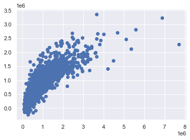

```python
plt.scatter(y_train,Train_prediction)
plt.show()
```

**Visualize our Predictions on Test Data**

```python
Test_prediction = olsmod2.predict(x_test3)
```

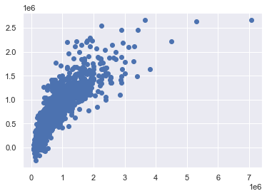

```python
plt.scatter(y_test,Test_prediction)
plt.show()
```

**Check other assumptions under OLS model**

**Test for Linearity and Indepenence on olsmod2**

```python
# let us create a dataframe with actual, fitted and residual values
df_pred = pd.DataFrame()

df_pred["Actual Values"] = y_train  # actual values
df_pred["Fitted Values"] = olsmod2.fittedvalues  # predicted values
df_pred["Residuals"] = olsmod2.resid  # residuals

df_pred.head()
```

|  | Actual Values | Fitted Values | Residuals |
| --- | --- | --- | --- |
| 753 | 834800.00 | 740827.74 | 93972.26 |
| 1418 | 350000.00 | 493540.53 | -143540.53 |
| 8183 | 1480000.00 | 1257369.79 | 222630.21 |
| 2254 | 218000.00 | 246764.47 | -28764.47 |
| 4066 | 687500.00 | 579106.99 | 108393.01 |

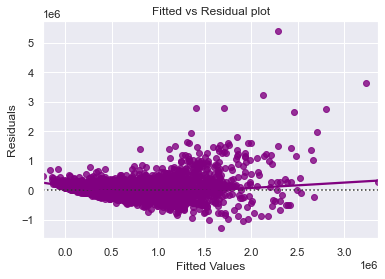

```python
# let's plot the fitted values vs residuals

sns.residplot(
    data=df_pred, x="Fitted Values", y="Residuals", color="purple", lowess=True
)
plt.xlabel("Fitted Values")
plt.ylabel("Residuals")
plt.title("Fitted vs Residual plot")
plt.show()
```

**Test for normality on olsmod2**

- We will test for normality by checking the distribution of residuals, by checking the Q-Q plot of residuals, and by using the Shapiro-Wilk test.
- If the residuals follow a normal distribution, they will make a straight line plot, otherwise not.
- If the p-value of the Shapiro-Wilk test is greater than 0.05, we can say the residuals are normally distributed.

**The distribution of residuals**

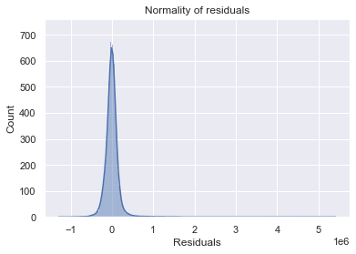

```python
sns.histplot(data=df_pred, x="Residuals", kde=True)
plt.title("Normality of residuals")
plt.show()
```

**Checking the Q-Q plot of residuals**

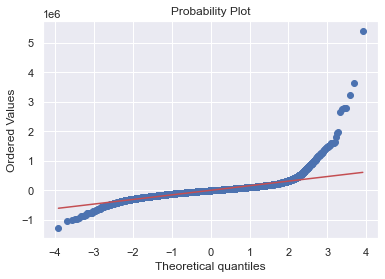

```python
import pylab
import scipy.stats as stats

stats.probplot(df_pred["Residuals"], dist="norm", plot=pylab)
plt.show()
```

**The Shapiro-Wilk test can also be used for checking the normality. The null and alternate hypotheses of the test are as follows:**

- Null hypothesis - Data is normally distributed.
- Alternate hypothesis - Data is not normally distributed.

```python
stats.shapiro(df_pred["Residuals"])
```

```
ShapiroResult(statistic=0.7340470552444458, pvalue=0.0)
```

**Test for Homoscedasticity**

- We will test for homoscedasticity by using the goldfeldquandt test.
- If we get a p-value greater than 0.05, we can say that the residuals are homoscedastic. Otherwise, they are heteroscedastic.

The null and alternate hypotheses of the goldfeldquandt test are as follows:

- Null hypothesis : Residuals are homoscedastic
- Alternate hypothesis : Residuals have hetroscedasticity

```python
import statsmodels.stats.api as sms
from statsmodels.compat import lzip

name = ["F statistic", "p-value"]
test = sms.het_goldfeldquandt(df_pred["Residuals"], x_train3)
lzip(name, test)
```

```
[('F statistic', 0.7960270028046514), ('p-value', 0.9999999999999999)]
```

- Since p-value > 0.05 we can say that the residuals are homoscedastic.

**..................................................................................................................................................................................................**

### Decision Tree Regressor Model

```python
from sklearn.tree import DecisionTreeRegressor
```

```python
df.info()
```

```
<class 'pandas.core.frame.DataFrame'>
Int64Index: 21597 entries, 0 to 21612
Data columns (total 20 columns):
 #   Column             Non-Null Count  Dtype
---  ------             --------------  -----
 0   price              21597 non-null  float64
 1   room_bed           21597 non-null  float64
 2   room_bath          21597 non-null  float64
 3   living_measure     21597 non-null  float64
 4   lot_measure        21597 non-null  float64
 5   ceil               21597 non-null  float64
 6   coast              21597 non-null  float64
 7   sight              21597 non-null  float64
 8   condition          21597 non-null  float64
 9   quality            21597 non-null  float64
 10  ceil_measure       21597 non-null  float64
 11  basement           21597 non-null  float64
 12  zipcode            21597 non-null  object
 13  lat                21597 non-null  float64
 14  long               21597 non-null  float64
 15  living_measure15   21597 non-null  float64
 16  lot_measure15      21597 non-null  float64
 17  furnished          21597 non-null  float64
 18  yrs_before_sold    21597 non-null  float64
 19  renovation_status  21597 non-null  object
dtypes: float64(18), object(2)
memory usage: 3.5+ MB
```

```python
df3  = df.copy()
```

```python
## Let's encode renovated to 1 and Notrenovated as 0 for further analysis

df3["renovation_status"] = df3["renovation_status"].apply(
    lambda x: 1 if x == "renovated" else 0
)
```

```python
X1 = df3.drop(["price"], axis=1)
y1 = df3["price"]

print(X1.head())
print(y1.head())
```

```
   room_bed  room_bath  living_measure  lot_measure  ceil  coast  sight  \
0      4.00       2.00         3050.00      9440.00  1.00   0.00   0.00
1      2.00       1.00          670.00      3101.00  1.00   0.00   0.00
2      4.00       3.00         3040.00      2415.00  2.00   1.00   4.00
3      3.00       3.00         1740.00      3721.00  2.00   0.00   0.00
4      2.00       1.00         1120.00      4590.00  1.00   0.00   0.00

   condition  quality  ceil_measure  basement  zipcode   lat    long  \
0       3.00     8.00       1800.00   1250.00 98034.00 47.72 -122.18
1       4.00     6.00        670.00      0.00 98118.00 47.55 -122.27
2       3.00     8.00       3040.00      0.00 98118.00 47.52 -122.26
3       3.00     8.00       1740.00      0.00 98002.00 47.34 -122.21
4       3.00     7.00       1120.00      0.00 98118.00 47.57 -122.28

   living_measure15  lot_measure15  furnished  yrs_before_sold  \
```

[output cut: 18 more lines]

```python
x1_train, x1_test, y1_train, y1_test = train_test_split(X1, y1, test_size=0.3, random_state=42)
```

```python
TreeMod = DecisionTreeRegressor().fit(x1_train,y1_train)
```

```python
# checking model performance on train set (seen 70% data)
print("Training Performance\n")
TreeMod_train_perf = model_performance_regression(TreeMod, x1_train, y1_train)
TreeMod_train_perf
```

```
Training Performance
```

|  | RMSE | MAE | R-squared | Adj. R-squared | MAPE |
| --- | --- | --- | --- | --- | --- |
| 0 | 3041.06 | 126.72 | 1.00 | 1.00 | 0.04 |

```python
# checking model performance on train set (seen 70% data)
print("Test Performance\n")
TreeMod_Test_perf = model_performance_regression(TreeMod, x1_test, y1_test)
TreeMod_Test_perf
```

```
Test Performance
```

|  | RMSE | MAE | R-squared | Adj. R-squared | MAPE |
| --- | --- | --- | --- | --- | --- |
| 0 | 181846.99 | 102022.04 | 0.76 | 0.76 | 18.62 |

**Visualize our Predictions on Train Data**

```python
TreeMod_Train_Prediction = TreeMod.predict(x1_train)
```

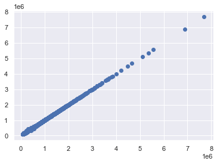

```python
plt.scatter(y1_train,TreeMod_Train_Prediction)
plt.show()
```

**Visualize our Predictions on Test Data**

```python
TreeMod_Test_Prediction = TreeMod.predict(x1_test)
```

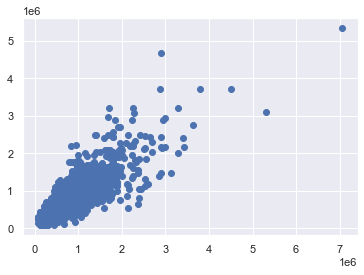

```python
plt.scatter(y1_test,TreeMod_Test_Prediction)
plt.show()
```

### Decision Tree Regressor Model - Hypertunning

```python
from sklearn.model_selection import GridSearchCV
```

```python
# Define parameter grid
param_grid = {
    'max_depth': [None, 10, 20, 30, 40, 50],
    'min_samples_split': [2, 5, 10, 20, 30],
    'min_samples_leaf': [1, 2, 5, 10],
    'max_features': ['auto','sqrt', None]
}
```

```python
# Create Decision Tree model
Tree_model = DecisionTreeRegressor()
```

```python
# GridSearchCV for hyperparameter tuning
grid_search = GridSearchCV(Tree_model, param_grid, cv=5)
```

```python
grid_search.fit(x1_train, y1_train)
```

```
GridSearchCV(cv=5, estimator=DecisionTreeRegressor(),
             param_grid={'max_depth': [None, 10, 20, 30, 40, 50],
                         'max_features': ['auto', 'sqrt', None],
                         'min_samples_leaf': [1, 2, 5, 10],
                         'min_samples_split': [2, 5, 10, 20, 30]})
```

```python
# Get the best parameters
grid_search.best_params_
```

```
{'max_depth': 30,
 'max_features': 'auto',
 'min_samples_leaf': 5,
 'min_samples_split': 30}
```

```python
Tree_Tunned_Mod = DecisionTreeRegressor(
    max_depth=20,
    max_features='auto',
    min_samples_leaf=5,
    min_samples_split=30
)
```

```python
Tree_Tunned_Mod = Tree_Tunned_Mod.fit(x1_train, y1_train)
```

```python
# checking model performance on train set (seen 70% data)
print("Training Performance\n")
Tree_Tunned_Mod_train_perf = model_performance_regression(Tree_Tunned_Mod, x1_train, y1_train)
Tree_Tunned_Mod_train_perf
```

```
Training Performance
```

|  | RMSE | MAE | R-squared | Adj. R-squared | MAPE |
| --- | --- | --- | --- | --- | --- |
| 0 | 119688.59 | 63209.73 | 0.89 | 0.89 | 11.60 |

**Visualize our Predictions**

```python
Tree_Tunned_Mod_Train_Prediction = Tree_Tunned_Mod.predict(x1_train)
```

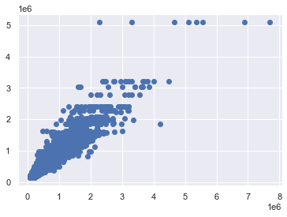

```python
plt.scatter(y1_train,Tree_Tunned_Mod_Train_Prediction)
plt.show()
```

```python
# checking model performance on train set (seen 70% data)
print("Test Performance\n")
Tree_Tunned_Mod_test_perf = model_performance_regression(Tree_Tunned_Mod, x1_test, y1_test)
Tree_Tunned_Mod_test_perf
```

```
Test Performance
```

|  | RMSE | MAE | R-squared | Adj. R-squared | MAPE |
| --- | --- | --- | --- | --- | --- |
| 0 | 164115.60 | 88583.43 | 0.81 | 0.80 | 15.88 |

**Visualize our Predictions**

```python
Tree_Tunned_Mod_Test_Prediction = Tree_Tunned_Mod.predict(x1_test)
```

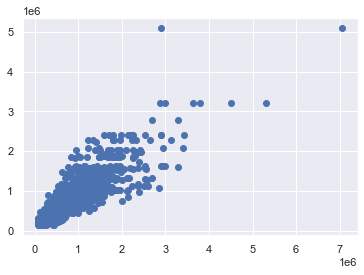

```python
plt.scatter(y1_test,Tree_Tunned_Mod_Test_Prediction)
plt.show()
```

**........................................................................................................................**

**Random Forest Regressor Model**

```python
from sklearn.ensemble import RandomForestRegressor
```

```python
# Create the Random forest model
rf = RandomForestRegressor()
```

```python
df.info()
```

```
<class 'pandas.core.frame.DataFrame'>
Int64Index: 21597 entries, 0 to 21612
Data columns (total 20 columns):
 #   Column             Non-Null Count  Dtype
---  ------             --------------  -----
 0   price              21597 non-null  float64
 1   room_bed           21597 non-null  float64
 2   room_bath          21597 non-null  float64
 3   living_measure     21597 non-null  float64
 4   lot_measure        21597 non-null  float64
 5   ceil               21597 non-null  float64
 6   coast              21597 non-null  float64
 7   sight              21597 non-null  float64
 8   condition          21597 non-null  float64
 9   quality            21597 non-null  float64
 10  ceil_measure       21597 non-null  float64
 11  basement           21597 non-null  float64
 12  zipcode            21597 non-null  object
 13  lat                21597 non-null  float64
 14  long               21597 non-null  float64
 15  living_measure15   21597 non-null  float64
 16  lot_measure15      21597 non-null  float64
 17  furnished          21597 non-null  float64
 18  yrs_before_sold    21597 non-null  float64
 19  renovation_status  21597 non-null  object
dtypes: float64(18), object(2)
memory usage: 3.5+ MB
```

```python
df4  = df.copy()
```

```python
## Let's encode renovated to 1 and Notrenovated as 0 for further analysis

df4["renovation_status"] = df4["renovation_status"].apply(
    lambda x: 1 if x == "renovated" else 0
)
```

```python
X2 = df4.drop(["price"], axis=1)
y2 = df4["price"]

print(X2.head())
print(y2.head())
```

```
   room_bed  room_bath  living_measure  lot_measure  ceil  coast  sight  \
0      4.00       2.00         3050.00      9440.00  1.00   0.00   0.00
1      2.00       1.00          670.00      3101.00  1.00   0.00   0.00
2      4.00       3.00         3040.00      2415.00  2.00   1.00   4.00
3      3.00       3.00         1740.00      3721.00  2.00   0.00   0.00
4      2.00       1.00         1120.00      4590.00  1.00   0.00   0.00

   condition  quality  ceil_measure  basement  zipcode   lat    long  \
0       3.00     8.00       1800.00   1250.00 98034.00 47.72 -122.18
1       4.00     6.00        670.00      0.00 98118.00 47.55 -122.27
2       3.00     8.00       3040.00      0.00 98118.00 47.52 -122.26
3       3.00     8.00       1740.00      0.00 98002.00 47.34 -122.21
4       3.00     7.00       1120.00      0.00 98118.00 47.57 -122.28

   living_measure15  lot_measure15  furnished  yrs_before_sold  \
```

[output cut: 18 more lines]

```python
x2_train, x2_test, y2_train, y2_test = train_test_split(X2, y2, test_size=0.3, random_state=42)
```

```python
rf_Mod = rf.fit(x2_train,y2_train)
```

```python
# checking model performance on train set (seen 70% data)
print("Training Performance\n")
rf_Mod_train_perf = model_performance_regression(rf_Mod, x2_train, y2_train)
rf_Mod_train_perf
```

```
Training Performance
```

|  | RMSE | MAE | R-squared | Adj. R-squared | MAPE |
| --- | --- | --- | --- | --- | --- |
| 0 | 48678.37 | 25945.45 | 0.98 | 0.98 | 4.92 |

```python
# checking model performance on test set (seen 30% data)
print("Test Performance\n")
rf_Mod_test_perf = model_performance_regression(rf_Mod, x2_test, y2_test)
rf_Mod_test_perf
```

```
Test Performance
```

|  | RMSE | MAE | R-squared | Adj. R-squared | MAPE |
| --- | --- | --- | --- | --- | --- |
| 0 | 132558.54 | 70525.86 | 0.87 | 0.87 | 12.98 |

**Random Forest Regressor Model - Hupertunning**

```python
param_grid_rf = {
    'max_depth': [3, 5, 7],
    'min_samples_leaf': [5, 10, 15],
    'min_samples_split': [15, 30, 45],
    'n_estimators': [25, 50]
}
```

```python
rf_reg = RandomForestRegressor()
```

```python
grid_search_rf = GridSearchCV(rf_reg, param_grid_rf, cv=5)
```

```python
grid_search_rf.fit(x2_train, y2_train)
```

```
GridSearchCV(cv=5, estimator=RandomForestRegressor(),
             param_grid={'max_depth': [3, 5, 7],
                         'min_samples_leaf': [5, 10, 15],
                         'min_samples_split': [15, 30, 45],
                         'n_estimators': [25, 50]})
```

```python
# Get the best parameters
grid_search_rf.best_params_
```

```
{'max_depth': 7,
 'min_samples_leaf': 5,
 'min_samples_split': 15,
 'n_estimators': 25}
```

```python
rf_Tunned_Mod = RandomForestRegressor(
    max_depth=7,
    min_samples_leaf=5,
    min_samples_split=15,
    n_estimators=50
)
```

```python
rf_Tunned_Mod = rf_Tunned_Mod.fit(x2_train, y2_train)
```

```python
# checking model performance on train set (seen 70% data)
print("Training Performance\n")
rf_Tunned_Mod_train_perf = model_performance_regression(rf_Tunned_Mod, x2_train, y2_train)
rf_Tunned_Mod_train_perf
```

```
Training Performance
```

|  | RMSE | MAE | R-squared | Adj. R-squared | MAPE |
| --- | --- | --- | --- | --- | --- |
| 0 | 135397.34 | 81995.00 | 0.86 | 0.86 | 16.12 |

```python
# checking model performance on test set (seen 30% data)
print("Test Performance\n")
rf_Tunned_Mod_test_perf = model_performance_regression(rf_Tunned_Mod, x2_test, y2_test)
rf_Tunned_Mod_test_perf
```

```
Test Performance
```

|  | RMSE | MAE | R-squared | Adj. R-squared | MAPE |
| --- | --- | --- | --- | --- | --- |
| 0 | 156704.65 | 88947.29 | 0.82 | 0.82 | 16.62 |

**...........................................................................................................................**

**XGBRegressor Model**

```python
from xgboost import XGBRegressor
```

```python
df5  = df.copy()
```

```python
## Let's encode renovated to 1 and Notrenovated as 0 for further analysis

df5["renovation_status"] = df5["renovation_status"].apply(
    lambda x: 1 if x == "renovated" else 0
)
```

```python
X3 = df5.drop(["price","zipcode" ], axis=1)
y3 = df5["price"]

print(X3.head())
print(y3.head())
```

```
   room_bed  room_bath  living_measure  lot_measure  ceil  coast  sight  \
0      4.00       2.00         3050.00      9440.00  1.00   0.00   0.00
1      2.00       1.00          670.00      3101.00  1.00   0.00   0.00
2      4.00       3.00         3040.00      2415.00  2.00   1.00   4.00
3      3.00       3.00         1740.00      3721.00  2.00   0.00   0.00
4      2.00       1.00         1120.00      4590.00  1.00   0.00   0.00

   condition  quality  ceil_measure  basement   lat    long  living_measure15  \
0       3.00     8.00       1800.00   1250.00 47.72 -122.18           2020.00
1       4.00     6.00        670.00      0.00 47.55 -122.27           1660.00
2       3.00     8.00       3040.00      0.00 47.52 -122.26           2620.00
3       3.00     8.00       1740.00      0.00 47.34 -122.21           2030.00
4       3.00     7.00       1120.00      0.00 47.57 -122.28           1120.00

   lot_measure15  furnished  yrs_before_sold  renovation_status
0        8660.00       0.00            49.00                  0
1        4100.00       0.00            67.00                  0
2        2433.00       0.00            48.00                  0
3        3794.00       0.00             5.00                  0
4        5100.00       0.00            91.00                  0
0   600000.00
1   190000.00
2   735000.00
3   257000.00
4   450000.00
Name: price, dtype: float64
```

```python
x3_train, x3_test, y3_train, y3_test = train_test_split(X3, y3, test_size=0.3, random_state=42)
```

```python
# load the model
xg = XGBRegressor()
```

```python
# Traing the model with x3_train
xgb=xg.fit(x3_train, y3_train)
```

```python
xgb
```

```
XGBRegressor(base_score=0.5, booster='gbtree', callbacks=None,
             colsample_bylevel=1, colsample_bynode=1, colsample_bytree=1,
             early_stopping_rounds=None, enable_categorical=False,
             eval_metric=None, feature_types=None, gamma=0, gpu_id=-1,
             grow_policy='depthwise', importance_type=None,
             interaction_constraints='', learning_rate=0.300000012, max_bin=256,
             max_cat_threshold=64, max_cat_to_onehot=4, max_delta_step=0,
             max_depth=6, max_leaves=0, min_child_weight=1, missing=nan,
             monotone_constraints='()', n_estimators=100, n_jobs=0,
             num_parallel_tree=1, predictor='auto', random_state=0, ...)
```

```python
# checking model performance on train set (seen 70% data)
print("Training Performance\n")
xgb_train_perf = model_performance_regression(xgb, x3_train, y3_train)
xgb_train_perf
```

```
Training Performance
```

|  | RMSE | MAE | R-squared | Adj. R-squared | MAPE |
| --- | --- | --- | --- | --- | --- |
| 0 | 56998.02 | 40549.90 | 0.98 | 0.98 | 9.03 |

```python
# checking model performance on test set (seen 30% data)
print("Test Performance\n")
xgb_test_perf = model_performance_regression(xgb, x3_test, y3_test)
xgb_test_perf
```

```
Test Performance
```

|  | RMSE | MAE | R-squared | Adj. R-squared | MAPE |
| --- | --- | --- | --- | --- | --- |
| 0 | 126688.00 | 70253.64 | 0.88 | 0.88 | 12.90 |

**XGBRegressor Model - Hupertuning**

```python
param_grid_xgb = {
    'n_estimators': [100, 200, 300],
    'max_depth': [3, 5, 7,10],
    'subsample': [0.8, 0.9, 1.0],
    'colsample_bytree': [0.8, 0.9, 1.0],
}
```

```python
xgb_re = XGBRegressor()
grid_search = GridSearchCV(xgb_re, param_grid_xgb, cv=5)
grid_search.fit(x3_train, y3_train)
```

```
GridSearchCV(cv=5,
             estimator=XGBRegressor(base_score=None, booster=None,
                                    callbacks=None, colsample_bylevel=None,
                                    colsample_bynode=None,
                                    colsample_bytree=None,
                                    early_stopping_rounds=None,
                                    enable_categorical=False, eval_metric=None,
                                    feature_types=None, gamma=None, gpu_id=None,
                                    grow_policy=None, importance_type=None,
                                    interaction_constraints=None,
                                    learning_rate=None, m...
                                    max_cat_threshold=None,
                                    max_cat_to_onehot=None, max_delta_step=None,
                                    max_depth=None, max_leaves=None,
                                    min_child_weight=None, missing=nan,
                                    monotone_constraints=None, n_estimators=100,
                                    n_jobs=None, num_parallel_tree=None,
                                    predictor=None, random_state=None, ...),
             param_grid={'colsample_bytree': [0.8, 0.9, 1.0],
                         'max_depth': [3, 5, 7, 10],
                         'n_estimators': [100, 200, 300],
                         'subsample': [0.8, 0.9, 1.0]})
```

```python
# Get the best parameters
grid_search.best_params_
```

```
{'colsample_bytree': 1.0,
 'max_depth': 3,
 'n_estimators': 300,
 'subsample': 1.0}
```

```python
xgb_reg = XGBRegressor(
    colsample_bytree = 1.0,
    max_depth = 3,
    n_estimators = 300,
    subsample = 1.0
)
```

```python
xgb_reg = xgb_reg.fit(x3_train, y3_train)
```

```python
# checking model performance on train set (seen 70% data)
print("Training Performance\n")
xgb_Mod_train_perf = model_performance_regression(xgb_reg, x3_train, y3_train)
xgb_Mod_train_perf
```

```
Training Performance
```

|  | RMSE | MAE | R-squared | Adj. R-squared | MAPE |
| --- | --- | --- | --- | --- | --- |
| 0 | 79639.41 | 54700.92 | 0.95 | 0.95 | 11.47 |

```python
# checking model performance on train set (seen 70% data)
print("Test Performance\n")
xgb_Mod_test_perf = model_performance_regression(xgb_reg, x3_test, y3_test)
xgb_Mod_test_perf
```

```
Test Performance
```

|  | RMSE | MAE | R-squared | Adj. R-squared | MAPE |
| --- | --- | --- | --- | --- | --- |
| 0 | 124680.15 | 70297.02 | 0.89 | 0.89 | 13.07 |

**Model Performance Comparison and Final Model Selection**

```python
# Concatenating the dataframes along columns
models_train_test_comp_df = pd.concat(
    [
        olsmod2_train_perf.T,
        olsmod2_test_perf.T,
        TreeMod_train_perf.T,
        TreeMod_Test_perf.T,
        Tree_Tunned_Mod_train_perf.T,
        Tree_Tunned_Mod_test_perf.T,
        rf_Mod_train_perf.T,
        rf_Mod_test_perf.T,
        rf_Tunned_Mod_train_perf.T,
        rf_Tunned_Mod_test_perf.T,
        xgb_train_perf.T,
        xgb_test_perf.T,
        xgb_Mod_train_perf.T,
        xgb_Mod_test_perf.T,
    ],
    axis=1,
)

# Renaming the columns with model names
models_train_test_comp_df.columns = [
    "Linear Regression_Train",
    "Linear Regression_Test",
    "Decision Tree_Train",
    "Decision Tree_Test",
    "Tunned Deccion Tree_Train",
    "Tunned Deccion Tree_Test",
    "Random Forest_Train",
    "Random Forest_Test",
    "Tunned Random Forest_Train",
    "Tunned Random Forest_Test",
    "XGBoost_Train",
    "XGBoost_Test",
    "Tunned XGBoost_Train",
    "Tunned XGBoost_Test",
]
print("model performance comparison:")
models_train_test_comp_df
```

```
model performance comparison:
```

|  | Linear Regression_Train | Linear Regression_Test | Decision Tree_Train | Decision Tree_Test | Tunned Deccion Tree_Train | Tunned Deccion Tree_Test | Random Forest_Train | Random Forest_Test | Tunned Random Forest_Train | Tunned Random Forest_Test | XGBoost_Train | XGBoost_Test | Tunned XGBoost_Train | Tunned XGBoost_Test |
| --- | --- | --- | --- | --- | --- | --- | --- | --- | --- | --- | --- | --- | --- | --- |
| RMSE | 181785.73 | 185359.29 | 3041.06 | 181846.99 | 119688.59 | 164115.60 | 48678.37 | 132558.54 | 135397.34 | 156704.65 | 56998.02 | 126688.00 | 79639.41 | 124680.15 |
| MAE | 106521.90 | 108567.58 | 126.72 | 102022.04 | 63209.73 | 88583.43 | 25945.45 | 70525.86 | 81995.00 | 88947.29 | 40549.90 | 70253.64 | 54700.92 | 70297.02 |
| R-squared | 0.75 | 0.75 | 1.00 | 0.76 | 0.89 | 0.81 | 0.98 | 0.87 | 0.86 | 0.82 | 0.98 | 0.88 | 0.95 | 0.89 |
| Adj. R-squared | 0.75 | 0.75 | 1.00 | 0.76 | 0.89 | 0.80 | 0.98 | 0.87 | 0.86 | 0.82 | 0.98 | 0.88 | 0.95 | 0.89 |
| MAPE | 21.60 | 21.63 | 0.04 | 18.62 | 11.60 | 15.88 | 4.92 | 12.98 | 16.12 | 16.62 | 9.03 | 12.90 | 11.47 | 13.07 |

```python
models_train_test_comp_df.to_csv('Downloads/METRICES.csv',index=False)
```

**Final Model & Important Features**

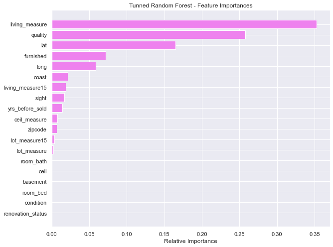

```python
feature_names = x2_test.columns
importances = rf_Tunned_Mod.feature_importances_
indices = np.argsort(importances)

plt.figure(figsize=(10, 8))
plt.title("Tunned Random Forest - Feature Importances")
plt.barh(range(len(indices)), importances[indices], color="violet", align="center")
plt.yticks(range(len(indices)), [feature_names[i] for i in indices])
plt.xlabel("Relative Importance")
plt.show()
```

**Important Features:**

- furnished
- Quality
- living_measure
- lat and Long (House Location)

**.....................................................END..............................................................................................................................................**